# Risk Factor Analysis

## Outcome Variable

**Outcome Variable:** sstunted

## Predictor Variables

**Intervention Variable:** feducyrs

**Adjustment Set:**

- arm
- W_mage
- meducyrs
- hhwealth_quart
- W_mhtcm
- W_mwtkg
- W_mbmi
- W_gagebrth
- W_birthwt
- W_birthlen
- single
- impsan
- delta_W_mage
- delta_meducyrs
- delta_hhwealth_quart
- delta_W_mhtcm
- delta_W_mwtkg
- delta_W_mbmi
- delta_W_gagebrth
- delta_W_birthwt
- delta_W_birthlen
- delta_single
- delta_impsan

## Stratifying Variables

The analysis was stratified on these variable(s):

- agecat
- studyid
- country

## Data Summary

| agecat | studyid | country | feducyrs | sstunted | n_cell | n |
| --- | --- | --- | --- | --- | --- | --- |
| Birth | COHORTS | GUATEMALA | High | 0 | 152 | 804 |
| Birth | COHORTS | GUATEMALA | High | 1 | 3 | 804 |
| Birth | COHORTS | GUATEMALA | Low | 0 | 348 | 804 |
| Birth | COHORTS | GUATEMALA | Low | 1 | 7 | 804 |
| Birth | COHORTS | GUATEMALA | Medium | 0 | 293 | 804 |
| Birth | COHORTS | GUATEMALA | Medium | 1 | 1 | 804 |
| Birth | COHORTS | INDIA | High | 0 | 516 | 1354 |
| Birth | COHORTS | INDIA | High | 1 | 11 | 1354 |
| Birth | COHORTS | INDIA | Low | 0 | 431 | 1354 |
| Birth | COHORTS | INDIA | Low | 1 | 8 | 1354 |
| Birth | COHORTS | INDIA | Medium | 0 | 379 | 1354 |
| Birth | COHORTS | INDIA | Medium | 1 | 9 | 1354 |
| Birth | COHORTS | PHILIPPINES | High | 0 | 1020 | 2873 |
| Birth | COHORTS | PHILIPPINES | High | 1 | 7 | 2873 |
| Birth | COHORTS | PHILIPPINES | Low | 0 | 810 | 2873 |
| Birth | COHORTS | PHILIPPINES | Low | 1 | 17 | 2873 |
| Birth | COHORTS | PHILIPPINES | Medium | 0 | 1000 | 2873 |
| Birth | COHORTS | PHILIPPINES | Medium | 1 | 19 | 2873 |
| Birth | GMS-Nepal | NEPAL | High | 0 | 165 | 694 |
| Birth | GMS-Nepal | NEPAL | High | 1 | 7 | 694 |
| Birth | GMS-Nepal | NEPAL | Low | 0 | 278 | 694 |
| Birth | GMS-Nepal | NEPAL | Low | 1 | 18 | 694 |
| Birth | GMS-Nepal | NEPAL | Medium | 0 | 220 | 694 |
| Birth | GMS-Nepal | NEPAL | Medium | 1 | 6 | 694 |
| Birth | JiVitA-3 | BANGLADESH | High | 0 | 4373 | 21624 |
| Birth | JiVitA-3 | BANGLADESH | High | 1 | 353 | 21624 |
| Birth | JiVitA-3 | BANGLADESH | Low | 0 | 8355 | 21624 |
| Birth | JiVitA-3 | BANGLADESH | Low | 1 | 1113 | 21624 |
| Birth | JiVitA-3 | BANGLADESH | Medium | 0 | 6565 | 21624 |
| Birth | JiVitA-3 | BANGLADESH | Medium | 1 | 865 | 21624 |

[output cut: 300 more lines]

The following strata were considered:

- agecat: 24 months, studyid: COHORTS, country: GUATEMALA
- agecat: 24 months, studyid: COHORTS, country: INDIA
- agecat: 24 months, studyid: COHORTS, country: PHILIPPINES
- agecat: 24 months, studyid: GMS-Nepal, country: NEPAL
- agecat: 24 months, studyid: JiVitA-3, country: BANGLADESH
- agecat: 24 months, studyid: JiVitA-4, country: BANGLADESH
- agecat: 24 months, studyid: LCNI-5, country: MALAWI
- agecat: 24 months, studyid: MAL-ED, country: BANGLADESH
- agecat: 24 months, studyid: MAL-ED, country: INDIA
- agecat: 24 months, studyid: MAL-ED, country: NEPAL
- agecat: 24 months, studyid: MAL-ED, country: PERU
- agecat: 24 months, studyid: MAL-ED, country: SOUTH AFRICA
- agecat: 24 months, studyid: MAL-ED, country: TANZANIA, UNITED REPUBLIC OF
- agecat: 24 months, studyid: NIH-Crypto, country: BANGLADESH
- agecat: 24 months, studyid: PROBIT, country: BELARUS
- agecat: 24 months, studyid: PROVIDE, country: BANGLADESH
- agecat: 24 months, studyid: TanzaniaChild2, country: TANZANIA, UNITED REPUBLIC OF
- agecat: 24 months, studyid: ZVITAMBO, country: ZIMBABWE
- agecat: 6 months, studyid: COHORTS, country: GUATEMALA
- agecat: 6 months, studyid: COHORTS, country: INDIA
- agecat: 6 months, studyid: COHORTS, country: PHILIPPINES
- agecat: 6 months, studyid: GMS-Nepal, country: NEPAL
- agecat: 6 months, studyid: JiVitA-3, country: BANGLADESH
- agecat: 6 months, studyid: JiVitA-4, country: BANGLADESH
- agecat: 6 months, studyid: LCNI-5, country: MALAWI
- agecat: 6 months, studyid: MAL-ED, country: BANGLADESH
- agecat: 6 months, studyid: MAL-ED, country: INDIA
- agecat: 6 months, studyid: MAL-ED, country: NEPAL
- agecat: 6 months, studyid: MAL-ED, country: PERU
- agecat: 6 months, studyid: MAL-ED, country: SOUTH AFRICA
- agecat: 6 months, studyid: MAL-ED, country: TANZANIA, UNITED REPUBLIC OF
- agecat: 6 months, studyid: NIH-Crypto, country: BANGLADESH
- agecat: 6 months, studyid: PROBIT, country: BELARUS
- agecat: 6 months, studyid: PROVIDE, country: BANGLADESH
- agecat: 6 months, studyid: SAS-CompFeed, country: INDIA
- agecat: 6 months, studyid: SAS-FoodSuppl, country: INDIA
- agecat: 6 months, studyid: TanzaniaChild2, country: TANZANIA, UNITED REPUBLIC OF
- agecat: 6 months, studyid: ZVITAMBO, country: ZIMBABWE
- agecat: Birth, studyid: COHORTS, country: GUATEMALA
- agecat: Birth, studyid: COHORTS, country: INDIA
- agecat: Birth, studyid: COHORTS, country: PHILIPPINES
- agecat: Birth, studyid: GMS-Nepal, country: NEPAL
- agecat: Birth, studyid: JiVitA-3, country: BANGLADESH
- agecat: Birth, studyid: JiVitA-4, country: BANGLADESH
- agecat: Birth, studyid: MAL-ED, country: BANGLADESH
- agecat: Birth, studyid: MAL-ED, country: INDIA
- agecat: Birth, studyid: MAL-ED, country: NEPAL
- agecat: Birth, studyid: MAL-ED, country: PERU
- agecat: Birth, studyid: MAL-ED, country: SOUTH AFRICA
- agecat: Birth, studyid: MAL-ED, country: TANZANIA, UNITED REPUBLIC OF
- agecat: Birth, studyid: NIH-Crypto, country: BANGLADESH
- agecat: Birth, studyid: PROBIT, country: BELARUS
- agecat: Birth, studyid: PROVIDE, country: BANGLADESH
- agecat: Birth, studyid: SAS-CompFeed, country: INDIA
- agecat: Birth, studyid: ZVITAMBO, country: ZIMBABWE

### Dropped Strata

Some strata were dropped due to rare outcomes:

- agecat: Birth, studyid: COHORTS, country: GUATEMALA
- agecat: Birth, studyid: MAL-ED, country: BANGLADESH
- agecat: Birth, studyid: MAL-ED, country: INDIA
- agecat: Birth, studyid: MAL-ED, country: NEPAL
- agecat: Birth, studyid: MAL-ED, country: PERU
- agecat: Birth, studyid: MAL-ED, country: SOUTH AFRICA
- agecat: Birth, studyid: MAL-ED, country: TANZANIA, UNITED REPUBLIC OF
- agecat: Birth, studyid: NIH-Crypto, country: BANGLADESH
- agecat: Birth, studyid: PROBIT, country: BELARUS
- agecat: Birth, studyid: PROVIDE, country: BANGLADESH
- agecat: 6 months, studyid: GMS-Nepal, country: NEPAL
- agecat: 6 months, studyid: MAL-ED, country: BANGLADESH
- agecat: 6 months, studyid: MAL-ED, country: INDIA
- agecat: 6 months, studyid: MAL-ED, country: NEPAL
- agecat: 6 months, studyid: MAL-ED, country: PERU
- agecat: 6 months, studyid: MAL-ED, country: SOUTH AFRICA
- agecat: 6 months, studyid: MAL-ED, country: TANZANIA, UNITED REPUBLIC OF
- agecat: 6 months, studyid: PROVIDE, country: BANGLADESH
- agecat: 24 months, studyid: MAL-ED, country: BANGLADESH
- agecat: 24 months, studyid: MAL-ED, country: INDIA
- agecat: 24 months, studyid: MAL-ED, country: NEPAL
- agecat: 24 months, studyid: MAL-ED, country: PERU
- agecat: 24 months, studyid: MAL-ED, country: SOUTH AFRICA
- agecat: 24 months, studyid: PROBIT, country: BELARUS
- agecat: 24 months, studyid: TanzaniaChild2, country: TANZANIA, UNITED REPUBLIC OF
- agecat: 24 months, studyid: ZVITAMBO, country: ZIMBABWE

## Methods Detail

We’re interested in the causal parameters $E[Y_a]$ for all values of $a \in \mathcal{A}$. These parameters represent the mean outcome if, possibly contrary to fact, we intervened to set all units to have $A=a$. Under the randomization and positivity assumptions, these are identified by the statistical parameters $\psi_a=E_W[E_{Y|A,W}(Y|A=a,W)]$. In addition, we’re interested in the mean of $Y$, $E[Y]$ under no intervention (the observed mean). We will estimate these parameters by using SuperLearner to fit the relevant likelihood factors – $E_{Y|A,W}(Y|A=a,W)$ and $p(A=a|W)$, and then updating our likelihood fit using a joint TMLE.

For unadjusted analyses ($W=\{\}$), initial likelihoods were estimated using Lrnr_glm to estimate the simple $E(Y|A)$ and Lrnr_mean to estimate $p(A)$. For adjusted analyses, a small library containing Lrnr_glmnet, Lrnr_xgboost, and Lrnr_mean was used.

Having estimated these parameters, we will then use the delta method to estimate relative risks and attributable risks relative to a prespecified baseline level of $A$.

# Results Detail

## Results Plots

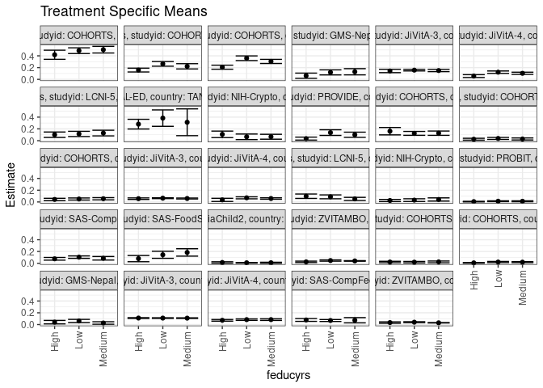

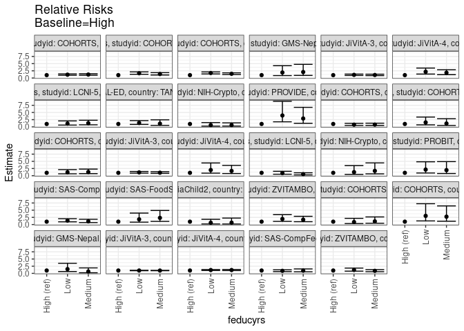

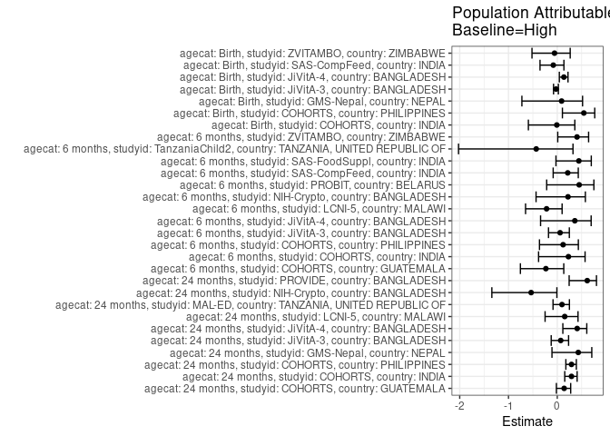

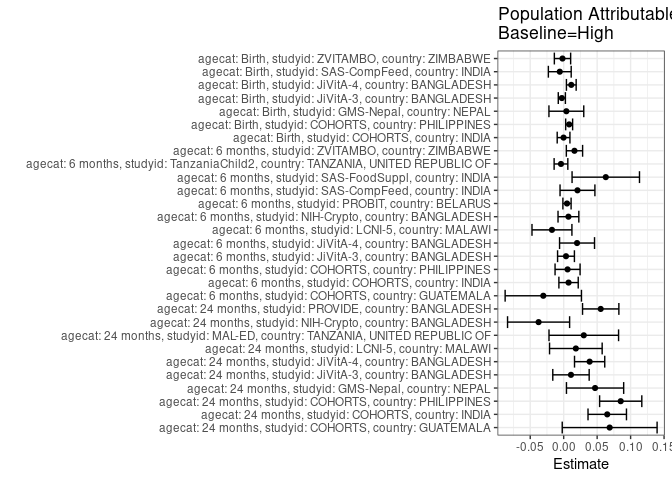

## Results Table

### Parameter: TSM

| agecat | studyid | country | intervention_level | baseline_level | estimate | ci_lower | ci_upper |
| --- | --- | --- | --- | --- | --- | --- | --- |
| Birth | COHORTS | INDIA | High | NA | 0.0208729 | 0.0086629 | 0.0330828 |
| Birth | COHORTS | INDIA | Low | NA | 0.0182232 | 0.0057064 | 0.0307401 |
| Birth | COHORTS | INDIA | Medium | NA | 0.0231959 | 0.0082128 | 0.0381790 |
| Birth | COHORTS | PHILIPPINES | High | NA | 0.0068160 | 0.0017831 | 0.0118489 |
| Birth | COHORTS | PHILIPPINES | Low | NA | 0.0205562 | 0.0108839 | 0.0302286 |
| Birth | COHORTS | PHILIPPINES | Medium | NA | 0.0186457 | 0.0103388 | 0.0269526 |
| Birth | GMS-Nepal | NEPAL | High | NA | 0.0406977 | 0.0111475 | 0.0702478 |
| Birth | GMS-Nepal | NEPAL | Low | NA | 0.0608108 | 0.0335661 | 0.0880555 |
| Birth | GMS-Nepal | NEPAL | Medium | NA | 0.0265487 | 0.0055745 | 0.0475229 |
| Birth | JiVitA-3 | BANGLADESH | High | NA | 0.1105743 | 0.1036782 | 0.1174703 |
| Birth | JiVitA-3 | BANGLADESH | Low | NA | 0.1099700 | 0.1047119 | 0.1152282 |
| Birth | JiVitA-3 | BANGLADESH | Medium | NA | 0.1088660 | 0.1033890 | 0.1143430 |
| Birth | JiVitA-4 | BANGLADESH | High | NA | 0.0722252 | 0.0581759 | 0.0862745 |
| Birth | JiVitA-4 | BANGLADESH | Low | NA | 0.0838069 | 0.0711746 | 0.0964391 |
| Birth | JiVitA-4 | BANGLADESH | Medium | NA | 0.0840234 | 0.0701054 | 0.0979414 |
| Birth | SAS-CompFeed | INDIA | High | NA | 0.0779073 | 0.0543135 | 0.1015011 |
| Birth | SAS-CompFeed | INDIA | Low | NA | 0.0687829 | 0.0521378 | 0.0854280 |
| Birth | SAS-CompFeed | INDIA | Medium | NA | 0.0734410 | 0.0289820 | 0.1179000 |
| Birth | ZVITAMBO | ZIMBABWE | High | NA | 0.0335652 | 0.0209854 | 0.0461449 |
| Birth | ZVITAMBO | ZIMBABWE | Low | NA | 0.0400273 | 0.0311463 | 0.0489083 |
| Birth | ZVITAMBO | ZIMBABWE | Medium | NA | 0.0297990 | 0.0264525 | 0.0331454 |
| 6 months | COHORTS | GUATEMALA | High | NA | 0.1610124 | 0.0982228 | 0.2238019 |
| 6 months | COHORTS | GUATEMALA | Low | NA | 0.1241081 | 0.0909250 | 0.1572912 |
| 6 months | COHORTS | GUATEMALA | Medium | NA | 0.1268985 | 0.0904537 | 0.1633433 |
| 6 months | COHORTS | INDIA | High | NA | 0.0244943 | 0.0084340 | 0.0405546 |
| 6 months | COHORTS | INDIA | Low | NA | 0.0377034 | 0.0208545 | 0.0545523 |
| 6 months | COHORTS | INDIA | Medium | NA | 0.0285054 | 0.0110781 | 0.0459326 |
| 6 months | COHORTS | PHILIPPINES | High | NA | 0.0425716 | 0.0225491 | 0.0625942 |
| 6 months | COHORTS | PHILIPPINES | Low | NA | 0.0502233 | 0.0326852 | 0.0677615 |
| 6 months | COHORTS | PHILIPPINES | Medium | NA | 0.0548403 | 0.0361013 | 0.0735792 |

[output cut: 57 more lines]

### Parameter: E(Y)

| agecat | studyid | country | intervention_level | baseline_level | estimate | ci_lower | ci_upper |
| --- | --- | --- | --- | --- | --- | --- | --- |
| Birth | COHORTS | INDIA | NA | NA | 0.0206795 | 0.0130966 | 0.0282623 |
| Birth | COHORTS | PHILIPPINES | NA | NA | 0.0149669 | 0.0105263 | 0.0194076 |
| Birth | GMS-Nepal | NEPAL | NA | NA | 0.0446686 | 0.0292885 | 0.0600487 |
| Birth | JiVitA-3 | BANGLADESH | NA | NA | 0.1077969 | 0.1031162 | 0.1124775 |
| Birth | JiVitA-4 | BANGLADESH | NA | NA | 0.0835766 | 0.0713713 | 0.0957819 |
| Birth | SAS-CompFeed | INDIA | NA | NA | 0.0720576 | 0.0515501 | 0.0925652 |
| Birth | ZVITAMBO | ZIMBABWE | NA | NA | 0.0317754 | 0.0288166 | 0.0347342 |
| 6 months | COHORTS | GUATEMALA | NA | NA | 0.1305310 | 0.1085580 | 0.1525039 |
| 6 months | COHORTS | INDIA | NA | NA | 0.0317690 | 0.0225290 | 0.0410089 |
| 6 months | COHORTS | PHILIPPINES | NA | NA | 0.0483619 | 0.0400565 | 0.0566674 |
| 6 months | JiVitA-3 | BANGLADESH | NA | NA | 0.0593851 | 0.0553716 | 0.0633986 |
| 6 months | JiVitA-4 | BANGLADESH | NA | NA | 0.0554489 | 0.0485553 | 0.0623426 |
| 6 months | LCNI-5 | MALAWI | NA | NA | 0.0800493 | 0.0613726 | 0.0987259 |
| 6 months | NIH-Crypto | BANGLADESH | NA | NA | 0.0321678 | 0.0192256 | 0.0451101 |
| 6 months | PROBIT | BELARUS | NA | NA | 0.0109796 | 0.0053040 | 0.0166552 |
| 6 months | SAS-CompFeed | INDIA | NA | NA | 0.0960240 | 0.0777684 | 0.1142796 |
| 6 months | SAS-FoodSuppl | INDIA | NA | NA | 0.1421053 | 0.1069532 | 0.1772573 |
| 6 months | TanzaniaChild2 | TANZANIA, UNITED REPUBLIC OF | NA | NA | 0.0094153 | 0.0052007 | 0.0136299 |
| 6 months | ZVITAMBO | ZIMBABWE | NA | NA | 0.0397437 | 0.0355730 | 0.0439145 |
| 24 months | COHORTS | GUATEMALA | NA | NA | 0.4868952 | 0.4557757 | 0.5180146 |
| 24 months | COHORTS | INDIA | NA | NA | 0.2231884 | 0.2012119 | 0.2451650 |
| 24 months | COHORTS | PHILIPPINES | NA | NA | 0.2921348 | 0.2736026 | 0.3106670 |
| 24 months | GMS-Nepal | NEPAL | NA | NA | 0.1088296 | 0.0811421 | 0.1365171 |
| 24 months | JiVitA-3 | BANGLADESH | NA | NA | 0.1536235 | 0.1447035 | 0.1625436 |
| 24 months | JiVitA-4 | BANGLADESH | NA | NA | 0.0948257 | 0.0851298 | 0.1045216 |
| 24 months | LCNI-5 | MALAWI | NA | NA | 0.1190893 | 0.0924996 | 0.1456790 |
| 24 months | MAL-ED | TANZANIA, UNITED REPUBLIC OF | NA | NA | 0.3107345 | 0.2423622 | 0.3791067 |
| 24 months | NIH-Crypto | BANGLADESH | NA | NA | 0.0700389 | 0.0479542 | 0.0921236 |
| 24 months | PROVIDE | BANGLADESH | NA | NA | 0.0899654 | 0.0666186 | 0.1133122 |

### Parameter: RR

| agecat | studyid | country | intervention_level | baseline_level | estimate | ci_lower | ci_upper |
| --- | --- | --- | --- | --- | --- | --- | --- |
| Birth | COHORTS | INDIA | High | High | 1.0000000 | 1.0000000 | 1.000000 |
| Birth | COHORTS | INDIA | Low | High | 0.8730586 | 0.3541786 | 2.152110 |
| Birth | COHORTS | INDIA | Medium | High | 1.1112933 | 0.4649040 | 2.656404 |
| Birth | COHORTS | PHILIPPINES | High | High | 1.0000000 | 1.0000000 | 1.000000 |
| Birth | COHORTS | PHILIPPINES | Low | High | 3.0158922 | 1.2564899 | 7.238901 |
| Birth | COHORTS | PHILIPPINES | Medium | High | 2.7355951 | 1.1548408 | 6.480097 |
| Birth | GMS-Nepal | NEPAL | High | High | 1.0000000 | 1.0000000 | 1.000000 |
| Birth | GMS-Nepal | NEPAL | Low | High | 1.4942085 | 0.6366137 | 3.507086 |
| Birth | GMS-Nepal | NEPAL | Medium | High | 0.6523388 | 0.2230853 | 1.907548 |
| Birth | JiVitA-3 | BANGLADESH | High | High | 1.0000000 | 1.0000000 | 1.000000 |
| Birth | JiVitA-3 | BANGLADESH | Low | High | 0.9945355 | 0.9396827 | 1.052590 |
| Birth | JiVitA-3 | BANGLADESH | Medium | High | 0.9845510 | 0.9306117 | 1.041617 |
| Birth | JiVitA-4 | BANGLADESH | High | High | 1.0000000 | 1.0000000 | 1.000000 |
| Birth | JiVitA-4 | BANGLADESH | Low | High | 1.1603553 | 1.0046447 | 1.340200 |
| Birth | JiVitA-4 | BANGLADESH | Medium | High | 1.1633530 | 0.9903836 | 1.366531 |
| Birth | SAS-CompFeed | INDIA | High | High | 1.0000000 | 1.0000000 | 1.000000 |
| Birth | SAS-CompFeed | INDIA | Low | High | 0.8828817 | 0.6219116 | 1.253361 |
| Birth | SAS-CompFeed | INDIA | Medium | High | 0.9426716 | 0.5694675 | 1.560457 |
| Birth | ZVITAMBO | ZIMBABWE | High | High | 1.0000000 | 1.0000000 | 1.000000 |
| Birth | ZVITAMBO | ZIMBABWE | Low | High | 1.1925254 | 0.7715347 | 1.843231 |
| Birth | ZVITAMBO | ZIMBABWE | Medium | High | 0.8877949 | 0.6004020 | 1.312753 |
| 6 months | COHORTS | GUATEMALA | High | High | 1.0000000 | 1.0000000 | 1.000000 |
| 6 months | COHORTS | GUATEMALA | Low | High | 0.7707986 | 0.4808188 | 1.235664 |
| 6 months | COHORTS | GUATEMALA | Medium | High | 0.7881289 | 0.4865061 | 1.276751 |
| 6 months | COHORTS | INDIA | High | High | 1.0000000 | 1.0000000 | 1.000000 |
| 6 months | COHORTS | INDIA | Low | High | 1.5392711 | 0.6964913 | 3.401845 |
| 6 months | COHORTS | INDIA | Medium | High | 1.1637544 | 0.4750661 | 2.850812 |
| 6 months | COHORTS | PHILIPPINES | High | High | 1.0000000 | 1.0000000 | 1.000000 |
| 6 months | COHORTS | PHILIPPINES | Low | High | 1.1797366 | 0.6569156 | 2.118657 |
| 6 months | COHORTS | PHILIPPINES | Medium | High | 1.2881875 | 0.7206920 | 2.302547 |

[output cut: 57 more lines]

### Parameter: PAR

| agecat | studyid | country | intervention_level | baseline_level | estimate | ci_lower | ci_upper |
| --- | --- | --- | --- | --- | --- | --- | --- |
| Birth | COHORTS | INDIA | High | NA | -0.0001934 | -0.0097082 | 0.0093214 |
| Birth | COHORTS | PHILIPPINES | High | NA | 0.0081510 | 0.0029606 | 0.0133414 |
| Birth | GMS-Nepal | NEPAL | High | NA | 0.0039709 | -0.0220469 | 0.0299888 |
| Birth | JiVitA-3 | BANGLADESH | High | NA | -0.0027774 | -0.0080937 | 0.0025389 |
| Birth | JiVitA-4 | BANGLADESH | High | NA | 0.0113515 | 0.0040792 | 0.0186237 |
| Birth | SAS-CompFeed | INDIA | High | NA | -0.0058496 | -0.0229139 | 0.0112146 |
| Birth | ZVITAMBO | ZIMBABWE | High | NA | -0.0017897 | -0.0139680 | 0.0103886 |
| 6 months | COHORTS | GUATEMALA | High | NA | -0.0304814 | -0.0875161 | 0.0265533 |
| 6 months | COHORTS | INDIA | High | NA | 0.0072746 | -0.0071707 | 0.0217200 |
| 6 months | COHORTS | PHILIPPINES | High | NA | 0.0057903 | -0.0129035 | 0.0244841 |
| 6 months | JiVitA-3 | BANGLADESH | High | NA | 0.0034399 | -0.0091429 | 0.0160227 |
| 6 months | JiVitA-4 | BANGLADESH | High | NA | 0.0199545 | -0.0061751 | 0.0460840 |
| 6 months | LCNI-5 | MALAWI | High | NA | -0.0175456 | -0.0473811 | 0.0122899 |
| 6 months | NIH-Crypto | BANGLADESH | High | NA | 0.0070782 | -0.0084639 | 0.0226203 |
| 6 months | PROBIT | BELARUS | High | NA | 0.0049335 | -0.0012046 | 0.0110716 |
| 6 months | SAS-CompFeed | INDIA | High | NA | 0.0205909 | -0.0054554 | 0.0466372 |
| 6 months | SAS-FoodSuppl | INDIA | High | NA | 0.0628973 | 0.0125139 | 0.1132808 |
| 6 months | TanzaniaChild2 | TANZANIA, UNITED REPUBLIC OF | High | NA | -0.0040618 | -0.0143016 | 0.0061780 |
| 6 months | ZVITAMBO | ZIMBABWE | High | NA | 0.0161024 | 0.0039487 | 0.0282561 |
| 24 months | COHORTS | GUATEMALA | High | NA | 0.0687013 | -0.0021854 | 0.1395881 |
| 24 months | COHORTS | INDIA | High | NA | 0.0650837 | 0.0363501 | 0.0938174 |
| 24 months | COHORTS | PHILIPPINES | High | NA | 0.0852062 | 0.0536736 | 0.1167387 |
| 24 months | GMS-Nepal | NEPAL | High | NA | 0.0468827 | 0.0041336 | 0.0896318 |
| 24 months | JiVitA-3 | BANGLADESH | High | NA | 0.0108859 | -0.0163150 | 0.0380867 |
| 24 months | JiVitA-4 | BANGLADESH | High | NA | 0.0387589 | 0.0161768 | 0.0613410 |
| 24 months | LCNI-5 | MALAWI | High | NA | 0.0181711 | -0.0211450 | 0.0574872 |
| 24 months | MAL-ED | TANZANIA, UNITED REPUBLIC OF | High | NA | 0.0300327 | -0.0219599 | 0.0820253 |
| 24 months | NIH-Crypto | BANGLADESH | High | NA | -0.0375340 | -0.0839085 | 0.0088404 |
| 24 months | PROVIDE | BANGLADESH | High | NA | 0.0553119 | 0.0281657 | 0.0824581 |

### Parameter: PAF

| agecat | studyid | country | intervention_level | baseline_level | estimate | ci_lower | ci_upper |
| --- | --- | --- | --- | --- | --- | --- | --- |
| Birth | COHORTS | INDIA | High | NA | -0.0093521 | -0.5922383 | 0.3601512 |
| Birth | COHORTS | PHILIPPINES | High | NA | 0.5445982 | 0.1054980 | 0.7681494 |
| Birth | GMS-Nepal | NEPAL | High | NA | 0.0888972 | -0.7252775 | 0.5188552 |
| Birth | JiVitA-3 | BANGLADESH | High | NA | -0.0257649 | -0.0763623 | 0.0224541 |
| Birth | JiVitA-4 | BANGLADESH | High | NA | 0.1358210 | 0.0423467 | 0.2201714 |
| Birth | SAS-CompFeed | INDIA | High | NA | -0.0811801 | -0.3536279 | 0.1364315 |
| Birth | ZVITAMBO | ZIMBABWE | High | NA | -0.0563243 | -0.5182737 | 0.2650726 |
| 6 months | COHORTS | GUATEMALA | High | NA | -0.2335185 | -0.7557551 | 0.1333826 |
| 6 months | COHORTS | INDIA | High | NA | 0.2289858 | -0.3830770 | 0.5701881 |
| 6 months | COHORTS | PHILIPPINES | High | NA | 0.1197283 | -0.3646413 | 0.4321745 |
| 6 months | JiVitA-3 | BANGLADESH | High | NA | 0.0579256 | -0.1795786 | 0.2476092 |
| 6 months | JiVitA-4 | BANGLADESH | High | NA | 0.3598712 | -0.3422003 | 0.6947067 |
| 6 months | LCNI-5 | MALAWI | High | NA | -0.2191852 | -0.6499969 | 0.0991422 |
| 6 months | NIH-Crypto | BANGLADESH | High | NA | 0.2200405 | -0.4347783 | 0.5760064 |
| 6 months | PROBIT | BELARUS | High | NA | 0.4493333 | -0.2170827 | 0.7508520 |
| 6 months | SAS-CompFeed | INDIA | High | NA | 0.2144349 | -0.0839263 | 0.4306693 |
| 6 months | SAS-FoodSuppl | INDIA | High | NA | 0.4426109 | -0.0267209 | 0.6974031 |
| 6 months | TanzaniaChild2 | TANZANIA, UNITED REPUBLIC OF | High | NA | -0.4314087 | -2.0243888 | 0.3225306 |
| 6 months | ZVITAMBO | ZIMBABWE | High | NA | 0.4051561 | 0.0099666 | 0.6425987 |
| 24 months | COHORTS | GUATEMALA | High | NA | 0.1411009 | -0.0177737 | 0.2751751 |
| 24 months | COHORTS | INDIA | High | NA | 0.2916090 | 0.1534916 | 0.4071910 |
| 24 months | COHORTS | PHILIPPINES | High | NA | 0.2916673 | 0.1761593 | 0.3909803 |
| 24 months | GMS-Nepal | NEPAL | High | NA | 0.4307898 | -0.1085570 | 0.7077279 |
| 24 months | JiVitA-3 | BANGLADESH | High | NA | 0.0708606 | -0.1242604 | 0.2321174 |
| 24 months | JiVitA-4 | BANGLADESH | High | NA | 0.4087381 | 0.1144857 | 0.6052118 |
| 24 months | LCNI-5 | MALAWI | High | NA | 0.1525838 | -0.2497983 | 0.4254159 |
| 24 months | MAL-ED | TANZANIA, UNITED REPUBLIC OF | High | NA | 0.0966507 | -0.0868678 | 0.2491820 |
| 24 months | NIH-Crypto | BANGLADESH | High | NA | -0.5359028 | -1.3410445 | -0.0076687 |
| 24 months | PROVIDE | BANGLADESH | High | NA | 0.6148134 | 0.2437471 | 0.8038107 |